# STAT340_project

12/02/2021

## R Markdown

```r
data <- read.csv("Levels_Fyi_Salary_Data.csv")
head(data)
```

```
##            timestamp   company level                        title
## 1  6/7/2017 11:33:27    Oracle    L3              Product Manager
## 2 6/10/2017 17:11:29      eBay  SE 2            Software Engineer
## 3 6/11/2017 14:53:57    Amazon    L7              Product Manager
## 4  6/17/2017 0:23:14     Apple    M1 Software Engineering Manager
## 5 6/20/2017 10:58:51 Microsoft    60            Software Engineer
## 6 6/21/2017 17:27:47 Microsoft    63            Software Engineer
##   totalyearlycompensation          location yearsofexperience yearsatcompany
## 1                  127000  Redwood City, CA               1.5            1.5
## 2                  100000 San Francisco, CA               5.0            3.0
## 3                  310000       Seattle, WA               8.0            0.0
## 4                  372000     Sunnyvale, CA               7.0            5.0
## 5                  157000 Mountain View, CA               5.0            3.0
## 6                  208000       Seattle, WA               8.5            8.5
##    tag basesalary stockgrantvalue bonus gender otherdetails cityid dmaid
```

[output cut: 27 more lines]

```r
# filter gender, drop NA and other in gender
filted_data <- data %>%
  filter(gender %in% c("Female", "Male"))
filted_data %>%
        group_by(gender) %>%
        summarise(n= n())
```

```
## # A tibble: 2 x 2
##   gender     n
## * <chr>  <int>
## 1 Female  6999
## 2 Male   35702
```

```r
# modify location column, drop location outside US and leave only state information
filted_data = filted_data %>%
  select(company, level, title, totalyearlycompensation, location, yearsofexperience, yearsatcompany, basesalary,
         stockgrantvalue, bonus, gender, Race, Education) %>%
  group_by(location) %>%
  mutate(new_location = strsplit(location, ', ')[[1]][2])



states <- c("AL", "AK", "AZ", "AR", "CA", "CO", "CT", "DC", "DE", "FL", "GA",
          "HI", "ID", "IL", "IN", "IA", "KS", "KY", "LA", "ME", "MD",
          "MA", "MI", "MN", "MS", "MO", "MT", "NE", "NV", "NH", "NJ",
          "NM", "NY", "NC", "ND", "OH", "OK", "OR", "PA", "RI", "SC",
          "SD", "TN", "TX", "UT", "VT", "VA", "WA", "WV", "WI", "WY")

filted_data <- filted_data %>%
  filter(new_location %in% states)

head(filted_data)
```

```
## # A tibble: 6 x 14
## # Groups:   location [5]
##   company level title totalyearlycomp… location yearsofexperien… yearsatcompany
##   <chr>   <chr> <chr>            <int> <chr>               <dbl>          <dbl>
## 1 GE Dig… Seni… Soft…           140000 San Ram…                4              4
## 2 Amazon  L5    Soft…           172000 Seattle…               12              2
## 3 Uber    L5    Soft…           325000 San Fra…                7              2
## 4 Micros… 60    Soft…           150000 Seattle…                4              0
## 5 Google  L6    Soft…           640000 Mountai…               11              4
## 6 Toyota… L3    Soft…           189000 Boston,…                0              0
## # … with 7 more variables: basesalary <dbl>, stockgrantvalue <dbl>,
## #   bonus <dbl>, gender <chr>, Race <chr>, Education <chr>, new_location <chr>
```

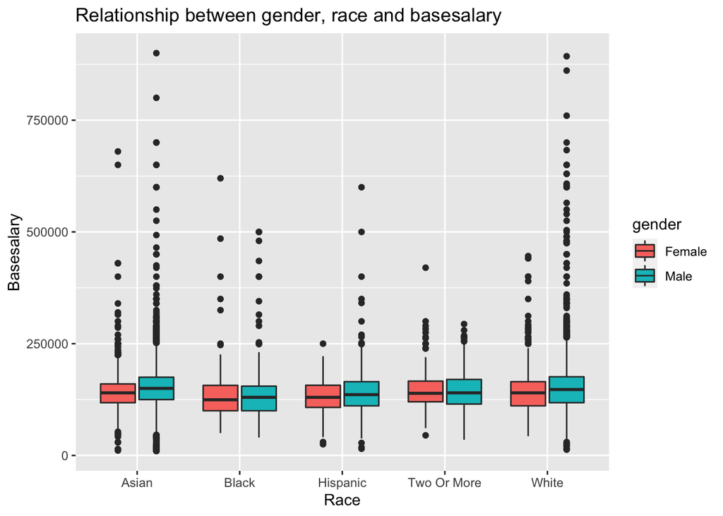

```r
filted_data1 <- filted_data %>%
  filter(!is.na(Race))
ggplot(filted_data1, aes(x = Race, y = basesalary, fill = gender)) +
  geom_boxplot()+ggtitle("Relationship between gender, race and basesalary")+ylab("Basesalary")
```

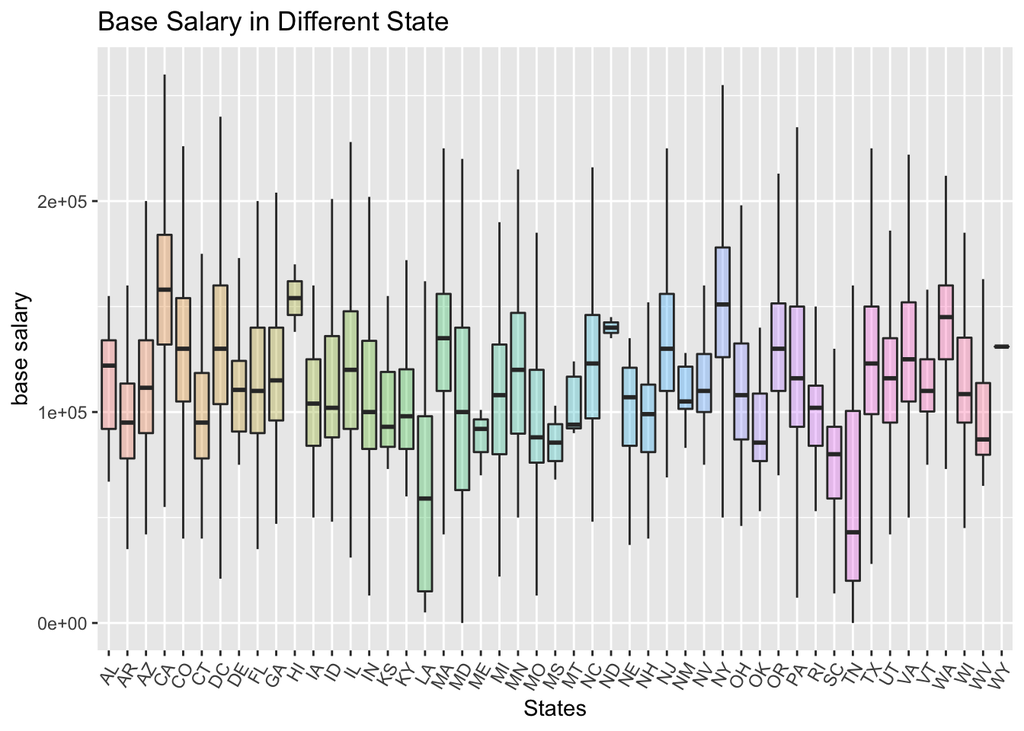

```r
ggplot(filted_data) +
  geom_boxplot(aes(x=as.character(new_location),y=basesalary, fill=new_location),
                outlier.shape = NA,alpha= 0.3) +
  theme(legend.position="none") +
  ylim(0, 260000) +
  ylab("base salary") +
  xlab("States") +
  scale_x_discrete(guide = guide_axis(angle = 60)) +
  ggtitle("Base Salary in Different State")
```

```
## geom_path: Each group consists of only one observation. Do you need to adjust
## the group aesthetic?
```

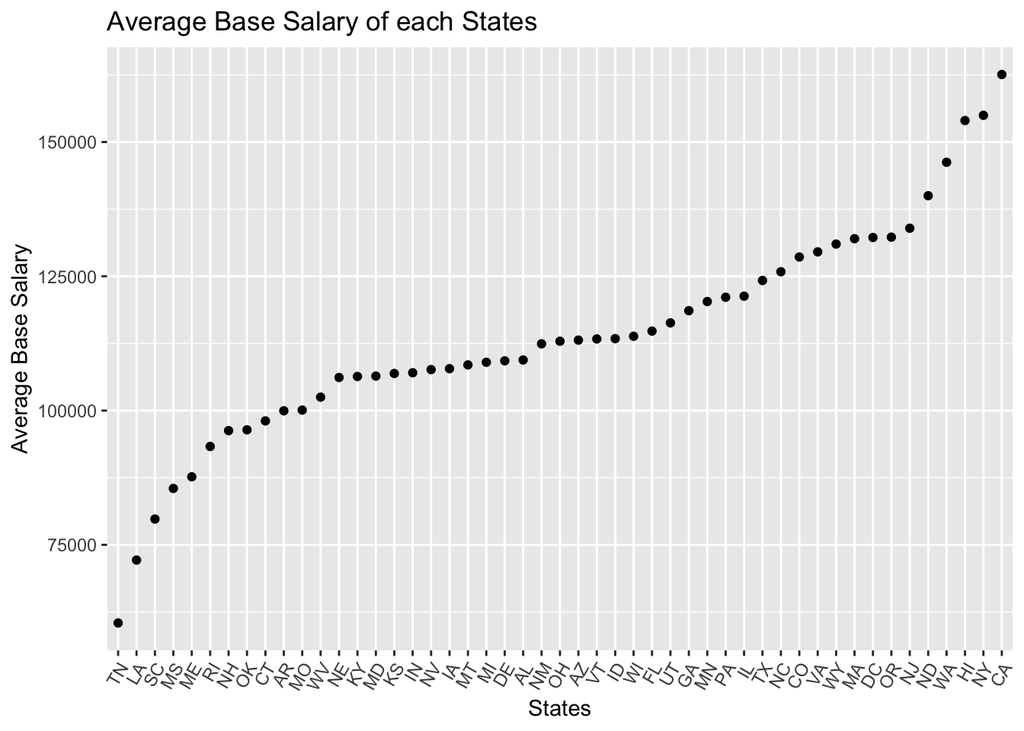

```r
state_mean=filted_data %>%
  group_by(new_location) %>%
  summarise(n= n(),
            mean_salary_state=mean(basesalary))

ggplot(state_mean, aes(x=reorder(new_location, mean_salary_state),y=mean_salary_state)) +
  geom_point() +
  geom_line() +
  scale_x_discrete(guide = guide_axis(angle = 60)) +
  ylab("Average Base Salary") +
  xlab("States") +
  ggtitle("Average Base Salary of each States")
```

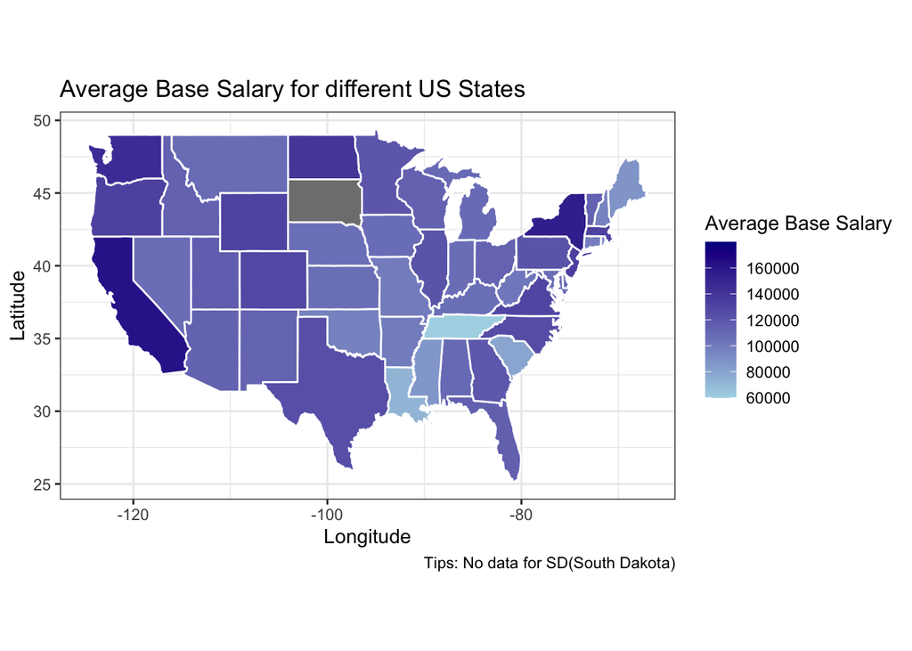

```r
library(lubridate)
states <- map_data("state") %>%
  select(-subregion) %>%
  mutate(new_location = state2abbr(region))

states = full_join(states, state_mean, by = "new_location")

ggplot(states, aes(x = long, y = lat, group = group, fill = mean_salary_state)) +
  geom_polygon(color = "white") +
  coord_fixed(1.5) +
  theme_bw()+ ggtitle("Average Base Salary for different US States") +
  xlab("Longitude")+
  ylab("Latitude")+
  labs(caption = "Tips: No data for SD(South Dakota)")+
  scale_fill_continuous(name="Average Base Salary",
            low = "lightblue", high = "darkblue",limits = c(60000,180000),
            breaks=c(60000,80000,100000,120000,140000,160000), na.value = "grey50")
```

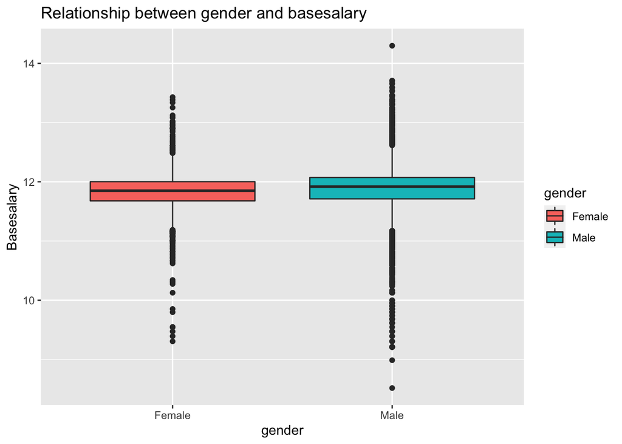

```r
filted_data %>%
  ggplot(aes(x = gender, y = log(basesalary), fill = gender)) +
  geom_boxplot()+ggtitle("Relationship between gender and basesalary")+ylab("Basesalary")
```

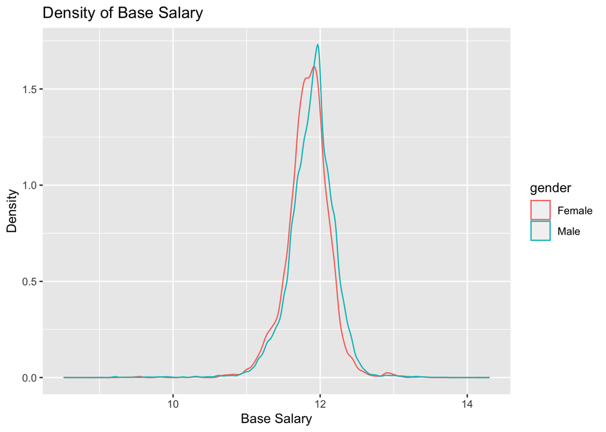

```r
ggplot(filted_data) +
  geom_density(aes(x = log(basesalary), color = gender), alpha = 0.2) +
  xlab('Base Salary') +
  ylab('Density') +
  ggtitle('Density of Base Salary')
```

```r
# using wilcoxon test to test whether the median income of the male and female
res <- wilcox.test(basesalary ~ gender, filted_data,var.equal = TRUE)
res
```

```
##
##  Wilcoxon rank sum test with continuity correction
##
## data:  basesalary by gender
## W = 82428772, p-value < 2.2e-16
## alternative hypothesis: true location shift is not equal to 0
```

```r
# We'll adapt the permutation testing approach we saw in lecture.
# Each MC replicate, we will randomly assign the data to two groups and compare their me ans.
# Then we'll see how the true difference in means compares to these.
male_data <- filted_data %>%
  filter(gender == "Male")
female_data <- filted_data %>%
  filter(gender == "Female")
Nrep <- 1000;
reps <- rep( NA, Nrep)
n <- nrow(filted_data);

n_male <- nrow(male_data)
n_female <- nrow(female_data)

for( i in 1:Nrep ) {
  inds <- sample(1:n, n_male, replace=FALSE );
  reps[i] <- median(filted_data[inds,]$basesalary) - mean(filted_data[-inds,]$basesalary)
  }
# Form the CI
CI <- as.vector( quantile(reps, probs = c(0.025,0.975)) );
# Note that we could get these means with a more graceful GroupBy operation,
# But I want to make it very clear what we are computing here.
Female_inds <- (filted_data$gender== "Female");
Female_salary <- filted_data[Female_inds,]$basesalary;
Female_median <- median(Female_salary);
Male_inds <- (filted_data$gender== "Male");
Male_salary <- filted_data[Male_inds,]$basesalary;
Male_median <- median(Male_salary);
popdiff <- Female_median-Male_median;

(CI[1] < popdiff) & (popdiff < CI[2]);
```

```
## [1] FALSE
```

```r
mlm <- lm(basesalary ~ 1+yearsofexperience+yearsatcompany+title+new_location,male_data)
summary(mlm)
```

```
##
## Call:
## lm(formula = basesalary ~ 1 + yearsofexperience + yearsatcompany +
##     title + new_location, data = male_data)
##
## Residuals:
##     Min      1Q  Median      3Q     Max
## -280984  -16763    -471   17686 1464403
##
## Coefficients:
##                                    Estimate Std. Error t value Pr(>|t|)
## (Intercept)                        57614.03   11691.32   4.928 8.36e-07 ***
## yearsofexperience                   4094.74      54.59  75.011  < 2e-16 ***
## yearsatcompany                     -1003.72      92.37 -10.867  < 2e-16 ***
## titleData Scientist                35688.89    3005.73  11.874  < 2e-16 ***
## titleHardware Engineer             18804.60    3014.62   6.238 4.50e-10 ***
## titleHuman Resources               10112.82    6183.70   1.635 0.101976
## titleManagement Consultant         29390.81    3567.74   8.238  < 2e-16 ***
## titleMarketing                     14431.54    4280.53   3.371 0.000749 ***
## titleMechanical Engineer            6344.50    3995.30   1.588 0.112299
## titleProduct Designer              20000.71    3333.31   6.000 1.99e-09 ***
## titleProduct Manager               26377.55    2901.11   9.092  < 2e-16 ***
## titleRecruiter                     -4363.88    5371.49  -0.812 0.416560
## titleSales                          -821.52    4706.89  -0.175 0.861446
## titleSoftware Engineer             25982.97    2714.39   9.572  < 2e-16 ***
## titleSoftware Engineering Manager  38354.49    2937.30  13.058  < 2e-16 ***
## titleSolution Architect            14753.14    3318.49   4.446 8.79e-06 ***
## titleTechnical Program Manager     19484.21    3334.98   5.842 5.20e-09 ***
## new_locationAR                     -6417.22   12795.21  -0.502 0.616000
## new_locationAZ                      4510.15   11761.42   0.383 0.701374
## new_locationCA                     54070.97   11378.29   4.752 2.02e-06 ***
## new_locationCO                     16755.62   11632.67   1.440 0.149767
## new_locationCT                    -15655.16   12263.94  -1.277 0.201782
## new_locationDC                     23115.90   11652.02   1.984 0.047281 *
## new_locationDE                      1461.09   13503.44   0.108 0.913837
## new_locationFL                      5368.32   11894.00   0.451 0.651743
## new_locationGA                      9207.96   11649.96   0.790 0.429309
## new_locationHI                     42400.04   34118.62   1.243 0.213979
## new_locationIA                     -2634.25   15093.59  -0.175 0.861452
## new_locationID                      3582.92   15099.36   0.237 0.812434
```

[output cut: 27 more lines]

```
## new_locationTN                    -43967.91   12081.38  -3.639 0.000274 ***
## new_locationTX                     14591.14   11428.16   1.277 0.201693
## new_locationUT                      9059.39   11954.51   0.758 0.448564
## new_locationVA                     22447.50   11525.42   1.948 0.051466 .
## new_locationVT                        77.36   23307.63   0.003 0.997352
## new_locationWA                     36005.64   11384.05   3.163 0.001564 **
## new_locationWI                     15839.63   12206.51   1.298 0.194422
## new_locationWV                     -5183.74   18334.51  -0.283 0.777385
## new_locationWY                     23758.43   46872.49   0.507 0.612247
## ---
## Signif. codes:  0 '***' 0.001 '**' 0.01 '*' 0.05 '.' 0.1 ' ' 1
##
## Residual standard error: 45470 on 29484 degrees of freedom
## Multiple R-squared:  0.3134, Adjusted R-squared:  0.3119
## F-statistic: 210.3 on 64 and 29484 DF,  p-value: < 2.2e-16
```

```r
flm <- lm(basesalary ~ 1+yearsofexperience+yearsatcompany+title+new_location,female_data)
summary(flm)
```

```
##
## Call:
## lm(formula = basesalary ~ 1 + yearsofexperience + yearsatcompany +
##     title + new_location, data = female_data)
##
## Residuals:
##     Min      1Q  Median      3Q     Max
## -230876  -15545    -710   16546  511156
##
## Coefficients:
##                                    Estimate Std. Error t value Pr(>|t|)
## (Intercept)                        63482.65   23838.28   2.663 0.007763 **
## yearsofexperience                   4430.86     121.41  36.496  < 2e-16 ***
## yearsatcompany                     -1810.87     207.77  -8.716  < 2e-16 ***
## titleData Scientist                33340.02    4132.00   8.069 8.44e-16 ***
## titleHardware Engineer             25396.95    4828.24   5.260 1.49e-07 ***
## titleHuman Resources                  21.62    5207.44   0.004 0.996688
## titleManagement Consultant         19228.54    5001.08   3.845 0.000122 ***
## titleMarketing                      9693.72    4565.61   2.123 0.033776 *
## titleMechanical Engineer           12646.95    7406.58   1.708 0.087774 .
## titleProduct Designer              23316.34    3942.74   5.914 3.52e-09 ***
## titleProduct Manager               27730.49    3755.25   7.384 1.73e-13 ***
## titleRecruiter                     -3813.58    4810.87  -0.793 0.427982
## titleSales                         -6060.92    6079.31  -0.997 0.318816
## titleSoftware Engineer             29758.84    3527.18   8.437  < 2e-16 ***
## titleSoftware Engineering Manager  43587.62    4561.63   9.555  < 2e-16 ***
## titleSolution Architect            14351.36    6800.84   2.110 0.034878 *
## titleTechnical Program Manager     24471.46    4426.55   5.528 3.36e-08 ***
## new_locationAR                     -9164.54   26606.84  -0.344 0.730525
## new_locationAZ                     -1828.98   24568.28  -0.074 0.940659
## new_locationCA                     40347.81   23586.80   1.711 0.087203 .
## new_locationCO                      8829.07   24057.69   0.367 0.713635
## new_locationCT                    -22686.17   25983.15  -0.873 0.382636
## new_locationDC                     14801.05   24023.41   0.616 0.537845
## new_locationDE                      9694.74   28191.41   0.344 0.730941
## new_locationFL                    -14965.85   24598.38  -0.608 0.542939
## new_locationGA                      9336.08   24103.55   0.387 0.698523
## new_locationIA                     11110.38   31191.77   0.356 0.721706
## new_locationID                    -44244.98   37323.77  -1.185 0.235890
## new_locationIL                      6046.86   23913.82   0.253 0.800384
```

[output cut: 22 more lines]

```
## new_locationRI                     24555.65   47257.41   0.520 0.603350
## new_locationSC                    -21620.64   33338.19  -0.649 0.516669
## new_locationTN                    -57654.23   26372.73  -2.186 0.028843 *
## new_locationTX                      5470.45   23690.05   0.231 0.817386
## new_locationUT                      4066.33   25203.71   0.161 0.871832
## new_locationVA                      8133.55   23998.80   0.339 0.734685
## new_locationVT                     -7793.09   47168.49  -0.165 0.868778
## new_locationWA                     24176.35   23599.25   1.024 0.305660
## new_locationWI                    -34584.04   28194.28  -1.227 0.220006
## ---
## Signif. codes:  0 '***' 0.001 '**' 0.01 '*' 0.05 '.' 0.1 ' ' 1
##
## Residual standard error: 40800 on 6266 degrees of freedom
## Multiple R-squared:  0.3136, Adjusted R-squared:  0.3071
## F-statistic: 48.52 on 59 and 6266 DF,  p-value: < 2.2e-16
```

```r
filted_data$company = toupper(filted_data$company)
companies <- filted_data %>% group_by(company)%>%
  summarise(n= n())

com_rela <- filted_data %>%
  group_by(company,gender)%>%
  summarise(basesalary=median(basesalary)) %>%
  pivot_wider(names_from = gender, values_from = basesalary) %>%
  drop_na() %>%
  mutate(sal_diff= Male -Female)
```

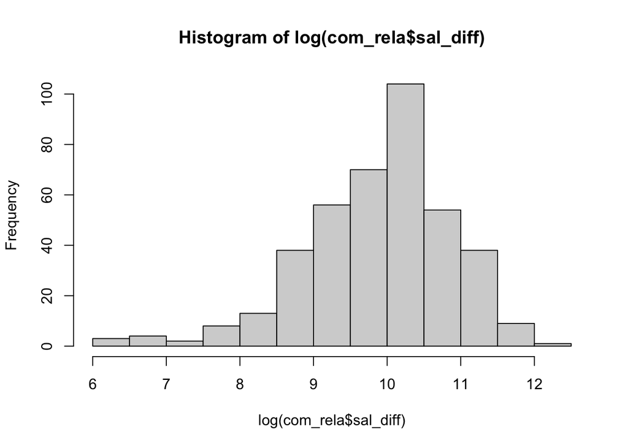

```r
hist(log(com_rela$sal_diff))
```

```r
mean(com_rela$sal_diff)
```

```
## [1] 10661.06
```

Is there any difference in gender gaps for different job positions?

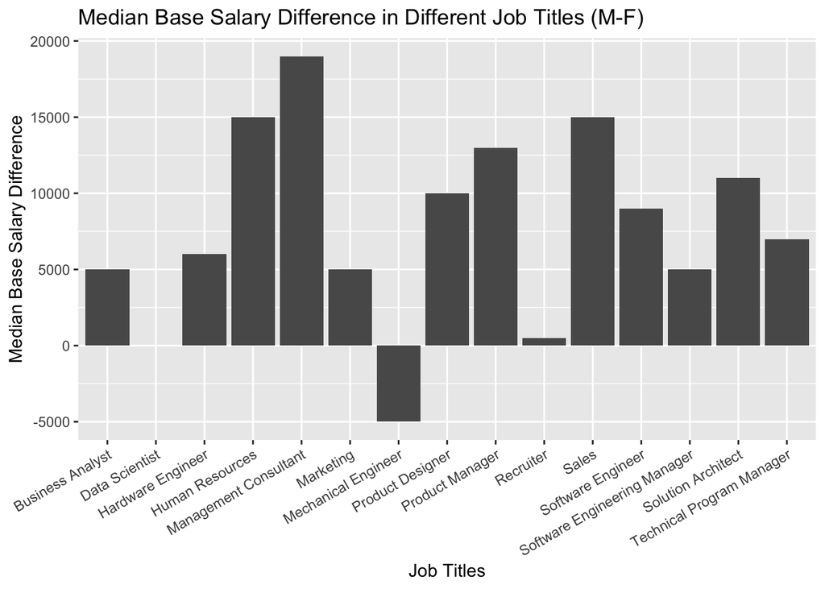

```r
title_diff <- filted_data %>%
  group_by(title, gender) %>%
  summarise(basesalary=median(basesalary))

basesalary <- title_diff$basesalary
tmp <- basesalary[2:30]
tmp[30] <- 0
title_diff$basesalary <- title_diff$basesalary - tmp
gap <- title_diff %>%
  filter(gender == "Female") %>%
  select(-2) %>%
  mutate(basesalary = basesalary * (-1))

ggplot(gap, aes(x=title, y=basesalary)) +
  geom_col() +
  scale_x_discrete(guide = guide_axis(angle = 30)) +
  ylab("Median Base Salary Difference") +
  xlab("Job Titles") +
  ggtitle("Median Base Salary Difference in Different Job Titles (M-F)")
```

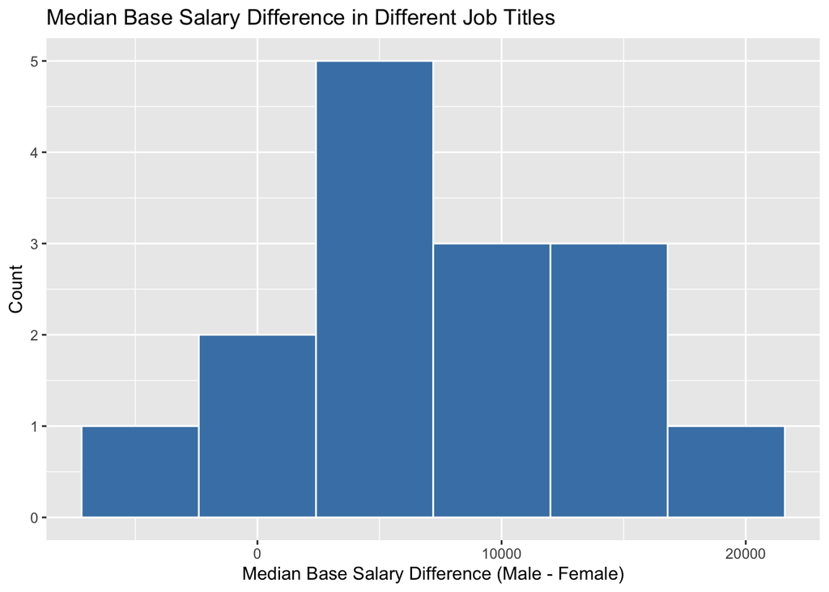

```r
ggplot(gap, aes(x=basesalary)) +
  geom_histogram(color="white", fill="steelblue", bins=6) +
  xlab("Median Base Salary Difference (Male - Female)") +
  ylab("Count") +
  ggtitle("Median Base Salary Difference in Different Job Titles")
```

From this histogram, we can see that for most job titles, male workers have a higher median base salary than female workers. For some job titles like Data Scientist, Recruiter, the difference is very small. For Management Consultant, Human resources, and Sales, the difference is relatively large. Therefore, it seems that, within each job title, there exists base salary differences of males and females.

Our null hypothesis is $H_0: $ No obvious gender base salary gap difference between each job title and $H_1:$ There exists gender base salary gap difference between each job title ***

```
##
##  Chi-Squared Test on Variance
##
## data:  gap$basesalary
## Chi-Squared = 5.779e+12, df = 14, p-value < 2.2e-16
## alternative hypothesis: true variance is not equal to 1e-04
## 95 percent confidence interval:
##   22125700 102669767
## sample estimates:
## variance
## 41278571
```

According to the chi-squared test, because the p-value is smaller than `2.2e-16`, which means the we can reject the null hypothesis that there is no obvious gender base salary gap difference between each job title.

Then we want to figure out how big the gender gap in base salary for different job titles. So for each job title, we conduct a two sample wilcoxon test to test whether the median base salary of male and female with that job title is equal. Then we show the test result as follows: ***

```r
job_title <- gap$title
results <- data.frame('Row'=rep(1:length(job_title)),
                      'Job_Title' = rep(NA, length(job_title)),
                      'P_Value' = rep(NA, length(job_title)))

for (i in 1:length(job_title)) {
  tmp <- filted_data %>%
    filter(title == job_title[i])
  res <- wilcox.test(basesalary ~ gender, tmp,var.equal = TRUE)
  results[i,]$P_Value = res$p.value
  results[i,]$Job_Title = job_title[i]
}
results <- results %>%
  mutate(significant = (P_Value <= 0.01))

results
```

```
##    Row                    Job_Title      P_Value significant
## 1    1             Business Analyst 2.589471e-01       FALSE
## 2    2               Data Scientist 1.582317e-01       FALSE
## 3    3            Hardware Engineer 3.938926e-02       FALSE
## 4    4              Human Resources 3.786281e-02       FALSE
## 5    5        Management Consultant 1.985219e-02       FALSE
## 6    6                    Marketing 1.608611e-02       FALSE
## 7    7          Mechanical Engineer 7.726088e-01       FALSE
## 8    8             Product Designer 7.676835e-05        TRUE
## 9    9              Product Manager 1.837483e-13        TRUE
## 10  10                    Recruiter 8.119364e-01       FALSE
## 11  11                        Sales 3.570879e-01       FALSE
## 12  12            Software Engineer 2.252637e-23        TRUE
## 13  13 Software Engineering Manager 1.572892e-01       FALSE
## 14  14           Solution Architect 4.079113e-03        TRUE
## 15  15    Technical Program Manager 2.647845e-03        TRUE
```

According to the results of our wilcoxon test, we find that we can reject the null hypothesis (Male workers have the same median base salary as female workers with the same job title) for 5 job titles. For the rest 10 job titles, we cannot reject the null hypothesis. ***

```
##   Row                 Job_Title      P_Value significant
## 1   8          Product Designer 7.676835e-05        TRUE
## 2   9           Product Manager 1.837483e-13        TRUE
## 3  12         Software Engineer 2.252637e-23        TRUE
## 4  14        Solution Architect 4.079113e-03        TRUE
## 5  15 Technical Program Manager 2.647845e-03        TRUE
```

In conclusion, gender gap presents differently in different job titles and in some jobs, there might not be a gender gap. From the above histogram and wilcoxon test, we find that there is strong evidence that gender gap exists in employees with job title “Product Designer”, “Product Manager”, “Software Engineer”, “Solution Architect”, and “Technical Program Manager”.